# Let’s Make Your R Code FastR: Part1

Simon Fraser University

## Introductions

## Introductions

### About Me

First-year Master's student studying Statistics

Research interests: machine learning, goodness-of-fit

### How About You?

## Why Are We Here?

How experienced are you with R?

What would you like to learn today?

- This is "Part 1", but we can cover more (or less)

## Outline

1. Why is R "slow"?
2. Timing Your R Code
3. Vectorization and Memory Allocation
4. Quick Fixes (That Make a Big Difference)
5. Advanced: Parallel Problems, Rcpp

## Why is R "slow"?

Often, R is "fast enough"

"The overriding concern for R-core is not to make R fast, but to build a stable platform for data analysis and statistics."

## Language vs. Implementation

Difference between language and implementation

Alternatives: pqR, Renjin, FastR, etc.

## Timing Your R Code

## Timing Your R Code

Bottlenecks need to be identified

Don't waste time optimizing code that is already fast enough

## Profiling / Timing Code

Depending on the circumstances, we can use one of:

- **profvis()**
- **bench::mark()**
- microbenchmark()
- system.time()
- utils::Rprof()
- utils::summaryRprof()

## bench::mark()

Great for code that takes several nano or milliseconds to run

Example: compare two "sqrt" functions

## bench::mark() - Example

```r
library(bench)

x <- runif(100)
bm1 <- bench::mark(
  x^0.5,
  sqrt(x)
)
```

## bench::mark() - Example

```
## # A tibble: 2 x 6
##   expression      min   median `itr/sec` mem_alloc `gc/sec`
##   <bch:expr> <bch:tm> <bch:tm>     <dbl> <bch:byt>    <dbl>
## 1 x^0.5         4.1us    4.4us   208345.      848B        0
## 2 sqrt(x)       600ns    700ns  1343616.      848B        0
```

## bench::mark() - Example

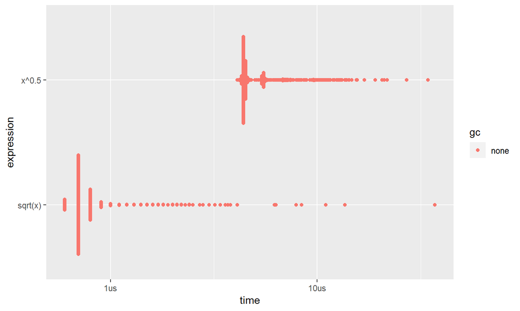

## bench::mark() - Limitations

Useful, but…

Let's see what we can do with profvis()

## profvis() - Example

Consider the function

```r
f <- function() {
  pause(0.1)
  g()
  h()
}
g <- function() {
  pause(0.1)
  h()
}
h <- function() {
  pause(0.1)
}
```

## profvis() - Example

Let's "profile" the function, f(), using profvis().

First, put f() in another file and then source that file.

```r
library(profvis)
source("../Simple R Functions.R")
profvis(f())
```

[interactive chart not shown]

## profvis() - What Do We See?

Flame graph: memory and time

Call stack

## Vectorization and Memory Allocation

## Vectorization

Don't think about elements of a vector

- Think about the entire vector as a unit

Loops in a vectorized function are in C

- Less overhead –> faster in C

## Vectorization - Example 1

Add two numeric vectors together, element by element

Non-vectorized version:

```r
vec1 <- 1:100
vec2 <- 101:200
vec3 <- numeric(100)

add_vecs1 <- function(vec1, vec2) {
  for (i in 1:length(vec1)) {
    vec3[i] <- vec1[i] + vec2[i]
  }
  return(vec3)
}
```

## Vectorization - Example 1

Vectorized version:

```r
add_vecs2 <- function(vec1, vec2) {
  vec3 <- vec1 + vec2
  return(vec3)
}
```

## Vectorization - Example 1

How do the times compare?

```r
bm2 <- bench::mark(
  add_vecs1(vec1, vec2),
  add_vecs2(vec1, vec2)
)
bm2
```

```
## # A tibble: 2 x 6
##   expression                 min   median `itr/sec` mem_alloc `gc/sec`
##   <bch:expr>            <bch:tm> <bch:tm>     <dbl> <bch:byt>    <dbl>
## 1 add_vecs1(vec1, vec2)   10.5us   10.8us    89874.   53.98KB      0
## 2 add_vecs2(vec1, vec2)    800ns    900ns   824435.    1.31KB     82.5
```

## Vectorization - Problem #1

The sample variance for observations \(x_1, \ldots, x_n\) is \[ \frac{1}{n-1} \sum_{i=1}^n (x_i - \bar{x})^2, \] where \(\bar{x}\) is the sample average.

**Problem 1:** Given a vector, "vec" with \(n\) (numeric) observations, write a vectorized R function that returns the sample variance.

## Vectorization - Problem #1 (Answer)

```r
myvar <- function(vec) {
  n <- length(vec)
  return( 1/(n-1) * sum((vec - mean(vec))^2) )
}
myvar(1:10)
```

```
## [1] 9.166667
```

```r
var(1:10)
```

```
## [1] 9.166667
```

## Vectorization (Again)

It is difficult to overemphasize vectorization in R!

There is almost always a way to vectorize

Useful functions: cumsum(), rowSums(), rowMeans(), etc.

## Preallocation - Example

This mistake can be seen (mostly out of carelessness)

Not preallocating:

```r
makemat1 <- function(nrow, ncol, seed) {
  set.seed(seed)
  mymat <- rnorm(ncol, 0, 1)
  for (i in 2:nrow) {
    mymat <- rbind(mymat, rnorm(ncol, 0, 1))
  }
  return(unname(mymat))
}
```

## Preallocation - Example

Preallocating:

```r
makemat2 <- function(nrow, ncol, seed) {
  set.seed(seed)
  mymat <- matrix(NA, nrow=nrow, ncol=ncol)
  for (i in 1:nrow) {
    mymat[i, ] <- rnorm(ncol, 0, 1)
  }
  return(mymat)
}
```

Even better:

```r
makemat3 <- function(nrow, ncol, seed) {
  set.seed(seed)
  mymat <- matrix(rnorm(nrow*ncol, 0, 1), nrow=nrow, ncol=ncol, byrow = TRUE)
  return(mymat)
}
```

## Preallocation - Example

```r
bm3 <- bench::mark(
  makemat1(nrow=10,ncol=10,seed=9823),
  makemat2(nrow=10,ncol=10,seed=9823),
  makemat3(nrow=10,ncol=10,seed=9823)
)
bm3
```

```
## # A tibble: 3 x 6
##   expression                                     min median `itr/sec` mem_alloc
##   <bch:expr>                                  <bch:> <bch:>     <dbl> <bch:byt>
## 1 makemat1(nrow = 10, ncol = 10, seed = 9823) 40.2us 43.7us    22010.   88.39KB
## 2 makemat2(nrow = 10, ncol = 10, seed = 9823) 28.8us 30.9us    31895.   73.63KB
## 3 makemat3(nrow = 10, ncol = 10, seed = 9823) 13.6us 14.5us    65846.    6.64KB
## # ... with 1 more variable: `gc/sec` <dbl>
```

## Preallocation - What's Happening?

Basically, whenever possible, state how much "memory" you will use at the beginning

Otherwise, R might be copying and moving your object around whenever you make a modification

## Copy-on-Modify and Modify-in-Place

Consider the following (somewhat surprising) example:

```r
X <- data.frame(matrix(rnorm(10000), ncol=4))
medians <- vapply(X, median, numeric(1))

cat(tracemem(X), "\n")
```

```
## <000000000E273530>
```

## Copy-on-Modify and Modify-in-Place

```r
for (i in 1:4) {
  X[[i]] <- X[[i]] - medians[[i]]
}
```

[output not shown]

```r
untracemem(X)
```

## Quick Fixes (That Make a Big Difference)

## Matrix Inversion - Not Necessary?

Often, we need to compute \(A^{-1} b\), for a matrix \(A\), and vector \(b\).

Although the answer is the same, there is a difference between two methods:

- Finding \(A^{-1}\) and multiplying by \(b\)
- Finding \(A^{-1} b\)

Think: the former uses Gaussian elimination and multiplication, the latter just uses Gaussian elimination

## Matrix Inversion - Not Necessary?

Matrix inversion in R with the solve() function

Consider the two examples:

```r
set.seed(29581)
# A <- matrix(rnorm(5000^2, 0, 1), nrow=5000, ncol=5000)
# b <- rnorm(5000, 0, 1)

# solve(A) %*% b # Get A inverse, and then multiply by b
# solve(A, b) # Get A inverse * b in one step!
```

## Matrix Inversion - Not Necessary?

Let's compare the times:

```r
# system.time(solve(A) %*% b) # 89.65 seconds
# system.time(solve(A, b)) # 19 seconds
```

## Matrix Inversion - Not Necessary?

I have personally used this trick **extensively**

Others have also saved **a lot** of time with this trick

## Use Linear Algebra Whenever Possible

The default BLAS (Basic Linear Algebra Subprogram) is good

- Doesn't do the calculations in R :)

Use linear algebra techniques whenever you can

Use order of operations wisely!

## Linear Algebra - Example

I won't give code here

- Not really specific to R

Regression: \(X \hat{\beta} = X (X^\top X)^{-1} X^\top y\)

\(\left(X (X^\top X)^{-1} X^\top \right) y\) versus \(X \left((X^\top X)^{-1} \left(X^\top y\right)\right)\)

"Big Data": the difference can be HUGE!

## Useful Functions - cumsum()

Many times I've had to get a running total or average in a relatively large dataset

cumsum() - cumulative sum

Good to know it exists

## Useful Data Structure - data.table

data.table - alternative to data.frame

Great for large datasets, subset, join, group, etc.

Very, very fast!

## The Apply Family

apply(), lapply(), sapply(), tapply()

These are often for loops in disguise *(not just my opinion)*

If you write your for loops well, "apply" functions are not always necessary

- Preallocation, remove indexing variables

Plus, you can then actually understand your code ;)

## Checkpoint - Problem #2

That's all for this section

Goal: make the code as fast as possible (there are small prizes)

- Use system.time(), third column
- Original time: My new time:

**See the Rmd file for the problem**

## Checkpoint - Problem #2

## Advanced Topics

## Parallel Computing in R

Say I have 4 cores

I will probably use 3 of them to run the code in parallel

Roughly speaking, 3x faster

- But, if you have Compute Canada access…

## Rcpp

Good if for loops are unavoidable

Write C++ code within R

I have seen **up to 20x faster** (maybe even more) implementations with this method!

Requires more effort (usually) than just running code in parallel

## Advanced Topics

Let's vote:

- Parallel computing in R
- Rcpp (Using C++ within R)

These topics were intended to be in Part 2 of the workshop (over the summer)

## Advanced Topics: Parallel Computing in R

## Available packages

We can use one of the following packages:

- "foreach" / "doParallel"
- "parallel"

## Advanced Topics: Rcpp